# Confidence intervals - minilab

author: “Del Middlemiss”  
date: “30th August 2019”

**Duration - 45 minutes**

# 1 Introduction

In this lab we’re going to draw multiple samples from a population, calculate a bootstrapped $95\%$ CI for each, and then see how often the population parameter lies within the CI. Hopefully this will help you to understand what we mean by ‘confidence’:

*‘If we draw 1000 repeated samples from a population, and form a $95\%$ CI for each for a parameter estimate, then, on average, we are *confident* that approximately $950$ CIs *will* contain the true population parameter, and approximately $50$ *will not*. This is what we will try to show below.’*

As in the earlier lab on sampling, do remember that this is something of a ‘fake’ situation, and we are doing this just for educational purposes. Normally, we would have a single sample drawn from a population, and a single CI created from that sample at whatever confidence level we like. We would not be able to repeatedly sample the population in the way that we will below.

# 2 MVP

- We are going to use a dataset on house sales in Ames, Iowa over a number of years. We will be interested in the `SalePrice` of houses (though we should `clean_names()` the data, so this will end up as `sale_price`). Load the data and explore it.

```r
library(tidyverse)
library(infer)
library(janitor)
```

```r
ames <- read_csv("data/ames.csv")
ames <- clean_names(ames)
glimpse(ames)
```

```
## Observations: 2,930
## Variables: 82
## $ order           <dbl> 1, 2, 3, 4, 5, 6, 7, 8, 9, 10, 11, 12, 13, 14, 1…
## $ pid             <dbl> 526301100, 526350040, 526351010, 526353030, 5271…
## $ ms_sub_class    <dbl> 20, 20, 20, 20, 60, 60, 120, 120, 120, 60, 60, 2…
## $ ms_zoning       <chr> "RL", "RH", "RL", "RL", "RL", "RL", "RL", "RL", …
## $ lot_frontage    <dbl> 141, 80, 81, 93, 74, 78, 41, 43, 39, 60, 75, NA,…
## $ lot_area        <dbl> 31770, 11622, 14267, 11160, 13830, 9978, 4920, 5…
## $ street          <chr> "Pave", "Pave", "Pave", "Pave", "Pave", "Pave", …
## $ alley           <chr> NA, NA, NA, NA, NA, NA, NA, NA, NA, NA, NA, NA, …
## $ lot_shape       <chr> "IR1", "Reg", "IR1", "Reg", "IR1", "IR1", "Reg",…
## $ land_contour    <chr> "Lvl", "Lvl", "Lvl", "Lvl", "Lvl", "Lvl", "Lvl",…
## $ utilities       <chr> "AllPub", "AllPub", "AllPub", "AllPub", "AllPub"…
## $ lot_config      <chr> "Corner", "Inside", "Corner", "Corner", "Inside"…
## $ land_slope      <chr> "Gtl", "Gtl", "Gtl", "Gtl", "Gtl", "Gtl", "Gtl",…
```

[output cut: 69 more lines]

- Plot a histogram of `sale_price`. Is the distribution normal?

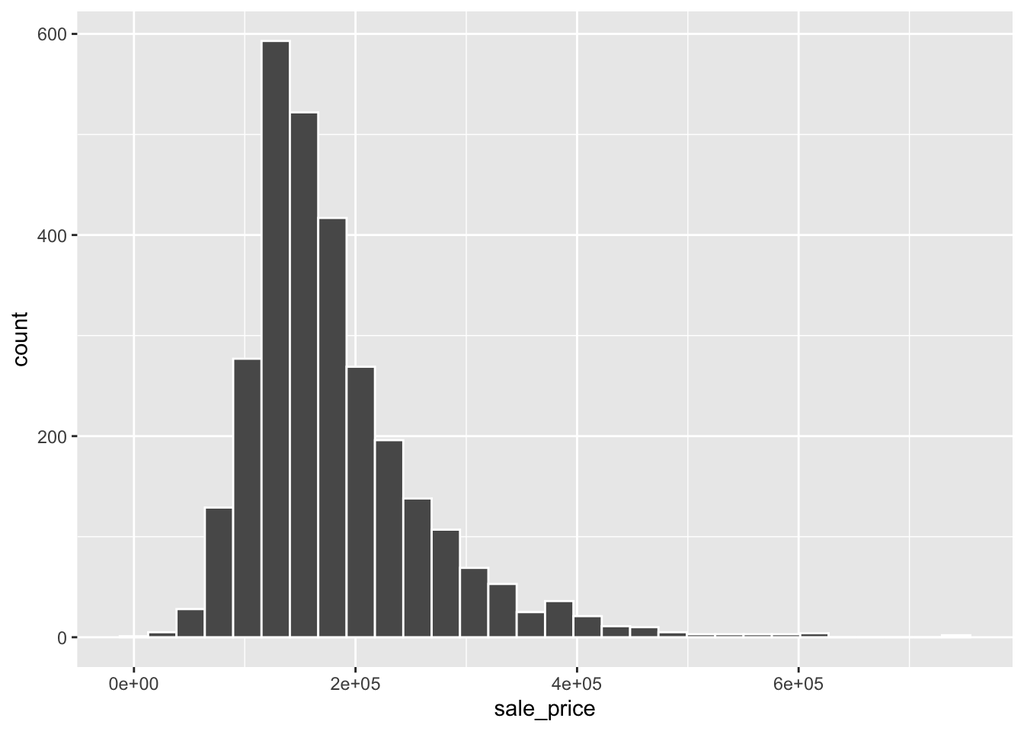

```r
ames %>%
  ggplot(aes(x = sale_price)) +
  geom_histogram(col = "white")
```

It is not normal, we see significant right-skew.

- Calculate the population parameter mean of `sale_price`. Store it in a variable, as we’ll need this value later when we check if each CI contains the parameter value or not.

```r
param <- ames %>%
  summarise(mean_sale_price = mean(sale_price))
param
```

| mean_sale_price |
| --- |
| 180796.1 |

- Now we are going to:
  - take $1000$ random samples each of size $100$ from `sale_price` in `ames`
  - create a boostrap sampling distribution of `mean(sale_price)` from each $100$-observation sample (use 1000 reps)
  - calculate the $95\%$ CI for each bootstrap distribution
  - store the upper and lower bounds of the CI in a tibble called `results`

Use the `infer` workflow to generate the bootstrap distributions and CIs. This code will be pretty hard to write. Think about wrapping the sample creation and `infer` code in a `for` loop to generate $1000$ random samples and CIs. Create an empty `results` tibble before the loop, and `bind_rows()` to it every time you generate a new set of CI bounds.

There’s an outline of the code below, and the full solution below that (if you get stuck). Have a go, but don’t spend too long on this, it’s more important to spend your time thinking about CIs!

**Code outline**

```r
results <- tibble()
for (sample_num in 1:1000){

  # get a new 100-observation random sample from ames
  this_sample <- ames %>%

  # create a bootstrap distribution of mean(sale_price)
  # use 1000 reps
  this_bootstrap <- this_sample %>%

  # get 95% CI for this_bootstrap distribution
  this_ci <- this_bootstrap %>%

  # prepare new row for results, storing this_ci bounds
  this_result <- c(
    sample_num = sample_num,
    lower = this_ci[[1]],
    upper = this_ci[[2]]
  )

  # add this_result to growing tibble of results
  results <-
}
```

**Full solution**

```r
results <- tibble()
for (sample_num in 1:1000){

  # get a new 100-observation random sample from ames
  this_sample <- ames %>%
    rep_sample_n(size = 100, reps = 1) %>%
    ungroup() %>%
    select(sale_price)

  # create a bootstrap distribution of mean(sale_price)
  # use 1000 reps
    this_bootstrap <- this_sample %>%
    specify(response = sale_price) %>%
    generate(reps = 1000, type = "bootstrap") %>%
    calculate(stat = "mean")

  # get 95% CI for this bootstrap distribution
  this_ci <- this_bootstrap %>%
    get_ci(level = 0.95, type = "percentile")

  # prepare new row for results, storing CI bounds
  this_result <- c(
    sample_num = sample_num,
    lower = this_ci[[1]],
    upper = this_ci[[2]]
  )

  # add this_result to growing tibble of results
  results <- bind_rows(results, this_result)
}
```

- Pipe `results` to `mutate()` to add a new variable `popn_param_in_ci` which will be `TRUE` if the population parameter we calculated earlier is between `lower` and `upper`, and `FALSE` otherwise.

```r
results <- results %>%
  mutate(popn_param_in_ci = lower <= param$mean_sale_price & param$mean_sale_price <= upper)
```

- Perform an appropriate `summarise()` to determine the proportion of CIs that contain the population parameter. Our confidence level was $95\%$. Is your proportion close to that value.

```r
results %>%
  summarise(proportion_CI_containing_popn_param = mean(popn_param_in_ci))
```

| proportion_CI_containing_popn_param |
| --- |
| 0.939 |

- Have a think about what all this means, make a list of any points you don’t understand.
  - Imagine you had only a single $100$-observation sample of the `ames` data (say from a $100$ house survey).
  - Would you know ahead of time whether the CI for `mean(sale_price)` from **your particular sample** contains the correct population parameter or not?